# Aim 3A: Continually evaluate the flow of clients served per county

**Report Goal**: a. Continually evaluate the flow of clients served per county.

**Report Description**: Part of a larger effort to evaluate engagement and retention of clients in EBHV services

# Demographics

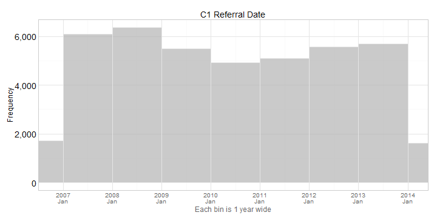

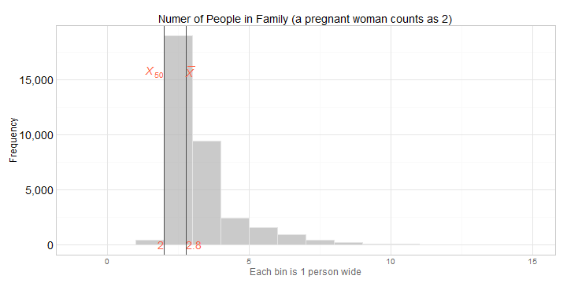

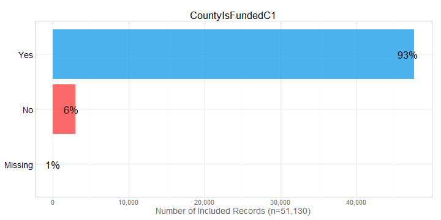

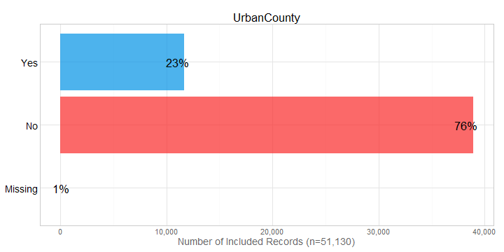

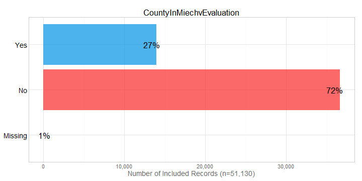

### Number of Referral Records for Each County

(asterisks mark counties not funded for C1)

| Response | Frequency | Response | Frequency | Response | Frequency | Response | Frequency | Response | Frequency |
| --- | --- | --- | --- | --- | --- | --- | --- | --- | --- |
| Tulsa[#72] | 6,266 | Washington[#74] | 813 | Choctaw[#12] | 461 | Pawnee[#59] | 197 | Alfalfa[#2] * | 26 |
| Oklahoma[#55] | 5,426 | Carter[#10] | 798 | Beckham[#5] | 456 | Kiowa[#38] * | 187 | Osage[#57] * | 25 |
| Cleveland[#14] | 2,717 | Kay[#36] | 765 | Kingfisher[#37] | 416 | Greer[#28] * | 183 | Roger Mills[#65] * | 20 |
| Garfield[#24] | 2,038 | Muskogee[#51] | 763 | McClain[#44] * | 391 | Okfuskee[#54] * | 180 | Ellis[#23] * | 13 |
| Comanche[#16] | 1,574 | Grady[#26] | 740 | Marshall[#48] | 352 | Adair[#1] | 175 | Greer[#28] | 6 |
| Pottawatomie[#63] | 1,464 | Sequoyah[#68] | 718 | Woodward[#77] | 349 | Love[#43] * | 150 | Pushmataha[#64] | 4 |
| Payne[#60] | 1,222 | Okmulgee[#56] | 666 | Atoka[#3] | 302 | Noble[#52] * | 146 | Love[#43] | 3 |
| Logan[#42] | 1,192 | Cherokee[#11] | 657 | Johnston[#35] | 294 | Major[#47] * | 142 | Dewey[#22] * | 2 |
| Bryan[#7] | 1,189 | Custer[#20] | 655 | Blaine[#6] | 287 | Woods[#76] * | 130 | Grant[#27] | 2 |
| Creek[#19] | 1,066 | Garvin[#25] | 641 | Latimer[#39] * | 287 | NA[#NA] | 126 | McClain[#44] | 2 |
| Le Flore[#40] | 1,066 | Lincoln[#41] | 627 | Craig[#18] | 285 | Cotton[#17] * | 123 | Okfuskee[#54] | 2 |
| Canadian[#9] | 1,044 | Seminole[#67] | 577 | Hughes[#32] | 282 | Jefferson[#34] * | 92 | Cleveland[#99] | 1 |
| Pittsburg[#61] | 1,017 | Caddo[#8] | 551 | Murray[#50] | 278 | Harmon[#29] * | 84 | Harmon[#29] | 1 |
| Rogers[#66] | 1,000 | Mayes[#49] | 519 | Wagoner[#73] | 271 | Harper[#30] * | 67 | Haskell[#31] | 1 |
| Stephens[#69] | 969 | Delaware[#21] | 494 | Haskell[#31] * | 225 | Washita[#75] * | 50 | Jefferson[#34] | 1 |
| Jackson[#33] | 948 | Texas[#70] | 479 | Pushmataha[#64] * | 202 | Grant[#27] * | 42 | Kiowa[#38] | 1 |
| Ottawa[#58] | 913 | Pontotoc[#62] | 473 | Coal[#15] | 201 | NA[#99] | 42 | Latimer[#39] | 1 |
| McCurtain[#45] | 817 | McIntosh[#46] | 465 | Tillman[#71] * | 198 | Beaver[#4] * | 36 | Woods[#76] | 1 |

### Number of Referral Records for Each Clinic

(asterisks mark counties not funded for C1)

| Response | Frequency | Response | Frequency | Response | Frequency | Response | Frequency | Response | Frequency | Response | Frequency |
| --- | --- | --- | --- | --- | --- | --- | --- | --- | --- | --- | --- |
| TULSA C1[#72] | 6,237 | SALLISAW[#68] | 718 | VINITA[#18] | 285 | CORDELL[#75] * | 49 | MIDTOWN HEALTH CLINIC[#72] | 6 | CORDELL MEMORIAL HOSPITAL[#75] * | 1 |
| CCHDOC[#55] | 5,399 | OKMULGEE[#56] | 661 | HOLDENVILLE[#32] | 282 | CUSHING[#60] | 48 | CLAYTON[#64] * | 5 | HEALDTON[#10] | 1 |
| NORMAN[#14] | 2,709 | TAHLEQUAH[#11] | 657 | SULPHUR[#50] | 278 | MEDFORD[#27] * | 42 | DRUMRIGHT[#19] | 5 | HOBART[#38] | 1 |
| ENID[#24] | 2,038 | PAULS VALLEY[#25] | 638 | WAGONER[#73] | 249 | BEAVER[#4] * | 36 | HENRYETTA[#56] | 5 | HOLLIS[#29] | 1 |
| LAWTON[#16] | 1,574 | CLINTON[#20] | 633 | WEWOKA[#67] | 242 | LAVERNE[#30] * | 36 | TCCHD-EXPO SQUARE[#72] | 5 | HOPE CENTER[#55] | 1 |
| SHAWNEE[#63] | 1,464 | CHANDLER[#41] | 627 | STIGLER[#31] * | 225 | BUFFALO[#30] * | 31 | ANTLERS[#64] | 4 | MARY MAHONEY[#55] | 1 |
| GUTHRIE[#42] | 1,192 | ANADARKO[#8] | 551 | COALGATE[#15] | 201 | ALFALFA[#2] * | 26 | BRISTOW[#19] | 4 | NSO NORTHWEST[#55] | 1 |
| DURANT[#7] | 1,189 | PRYOR[#49] | 519 | FREDERICK[#71] * | 198 | PAWHUSKA[#57] * | 25 | FAMILY CARE SERVICES[#74] | 4 | OKC SOONERSTART[#55] | 1 |
| STILLWATER[#60] | 1,174 | JAY[#21] | 494 | ANTLERS[#64] * | 197 | COWETA[#73] | 22 | VARIETY CARE MID-DEL[#55] | 4 | PHOCIS TEAM[#99] | 1 |
| POTEAU[#40] | 1,066 | GUYMON[#70] | 479 | HOBART[#38] * | 187 | ITSTESTING1[#99] | 22 | LINDSAY[#25] | 3 | QUERY ONLY[#99] | 1 |
| SAPULPA[#19] | 1,057 | ADA[#62] | 473 | MANGUM[#28] * | 183 | WEATHERFORD[#20] | 22 | MARIETTA[#43] | 3 | STIGLER[#31] | 1 |
| EL RENO[#9] | 1,023 | HUGO[#12] | 461 | OKEMAH[#54] * | 180 | YUKON[#9] | 21 | CCHDOC CAPITOL HILL[#55] | 2 | TCCHD-COLLINSVILLE[#72] | 1 |
| MCALESTER[#61] | 1,017 | CHECOTAH[#46] | 459 | STILWELL[#1] | 175 | ROGER MILLS CO. CHILDREN FIRST[#65] * | 20 | CCHDOC EAST[#55] | 2 | TCCHD Caring Van[#72] | 1 |
| CLAREMORE[#66] | 1,000 | ELK CITY[#5] | 454 | MARIETTA[#43] * | 150 | CHILDREN FIRST[#99] | 17 | CCHDOC TB[#55] | 2 | VARIETY CARE LAFAYETTE[#55] | 1 |
| DUNCAN[#69] | 969 | KINGFISHER[#37] | 416 | PERRY[#52] * | 146 | SHATTUCK[#23] * | 13 | DEWEY CO. CHILDREN FIRST[#22] * | 2 | VARIETY CARE STRAKA[#55] | 1 |
| ALTUS[#33] | 948 | PURCELL[#44] * | 381 | FAIRVIEW[#47] * | 142 | BLANCHARD[#44] * | 10 | ITSTESTING2[#99] | 2 | VARIETY[#55] | 1 |
| MIAMI[#58] | 913 | MADILL[#48] | 352 | ALVA[#76] * | 130 | BLACKWELL[#36] | 8 | MEDFORD[#27] | 2 | WAURIKA[#34] | 1 |
| IDABEL[#45] | 817 | WOODWARD[#77] | 349 | CLEVELAND[#59] | 126 | MOORE[#14] | 8 | NSO EAST[#55] | 2 | WILBURTON[#39] | 1 |
| BARTLESVILLE[#74] | 809 | SEMINOLE[#67] | 335 | NA[#NA] | 126 | TCCHD-JAMES GOODWIN[#72] | 8 | OKEMAH[#54] | 2 |  |  |
| ARDMORE[#10] | 797 | ATOKA[#3] | 302 | WALTERS[#17] * | 123 | TCCHD-SANDSPRINGS[#72] | 8 | PURCELL[#44] | 2 |  |  |
| MUSKOGEE[#51] | 763 | TISHOMINGO[#35] | 294 | WAURIKA[#34] * | 92 | CCHDOC WEST[#55] | 7 | SAYRE[#5] | 2 |  |  |
| PONCA CITY[#36] | 757 | WATONGA[#6] | 287 | HOLLIS[#29] * | 84 | EUFAULA[#46] | 6 | ALVA[#76] | 1 |  |  |
| CHICKASHA[#26] | 740 | WILBURTON[#39] * | 287 | PAWNEE[#59] | 71 | MANGUM[#28] | 6 | CCHDOC ROMINGER[#55] | 1 |  |  |

# Eligibility

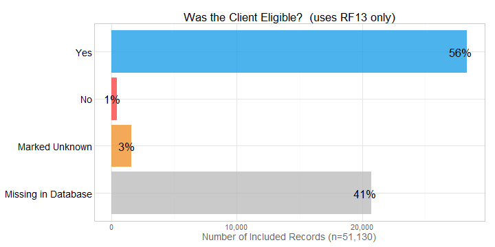

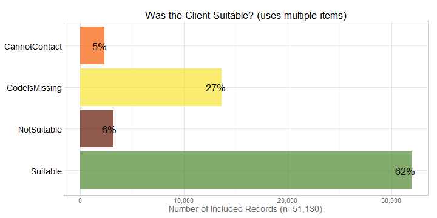

# Missing Records

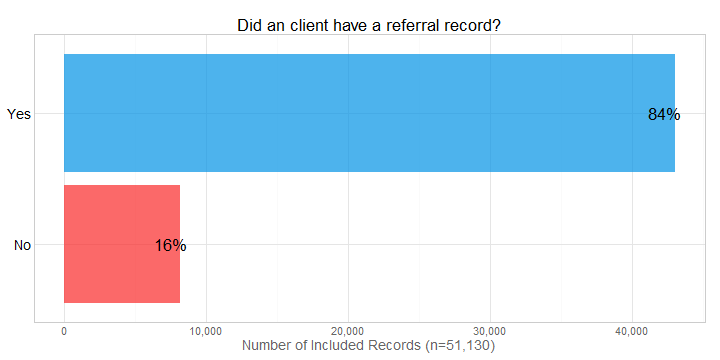

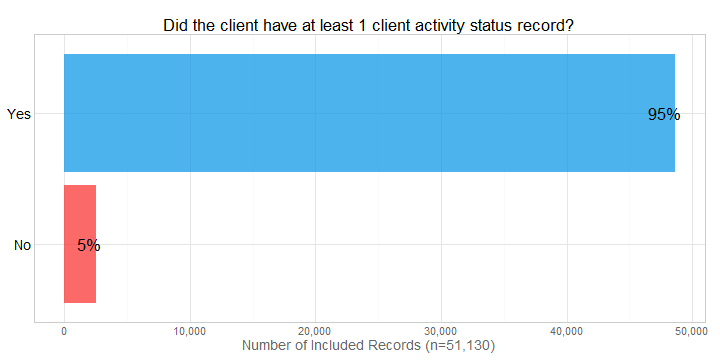

# Interview Completed

The following graphs describe the interview records by each nurse. A table displays the top open-ended responses why the potential client declined C1 services. The item stem is `RF20. Was an interview ever completed with the referred individual about participating in Children First?`

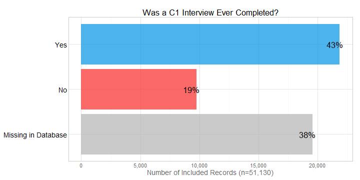

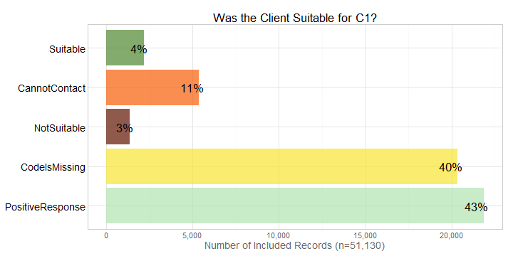

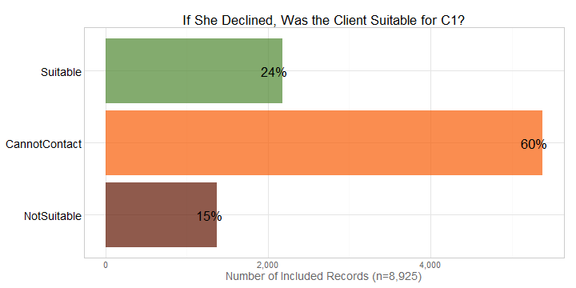

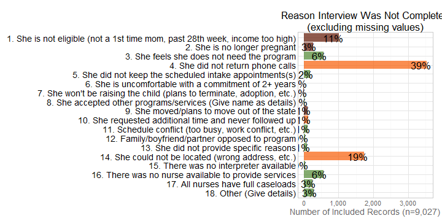

### Top Reasons Why Interview Was Not Completed

| Response | Frequency |
| --- | --- |
| pending | 67 |
| no respons | 26 |
| trans to p | 19 |
| unable to | 14 |
| no permiss | 10 |
| referred t | 5 |
| spoke with | 4 |
| could not | 3 |
| lives in o | 3 |
| mail only | 3 |

# Initial Visit

The following graphs describe the initial visit records by each nurse. A table displays the top open-ended responses why the potential client declined C1 services. The item stem is `RF22. Was the initial home visit completed?`

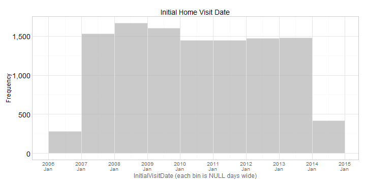

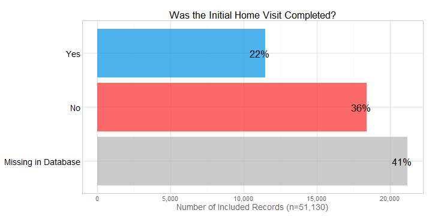

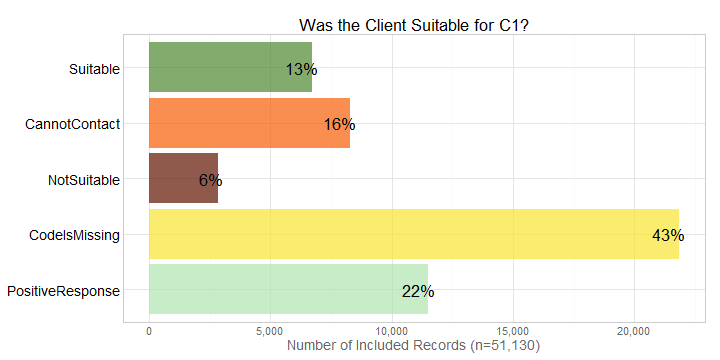

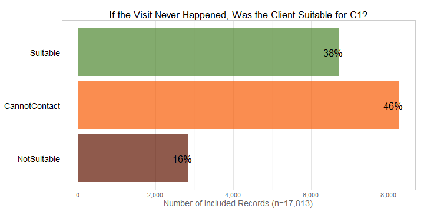

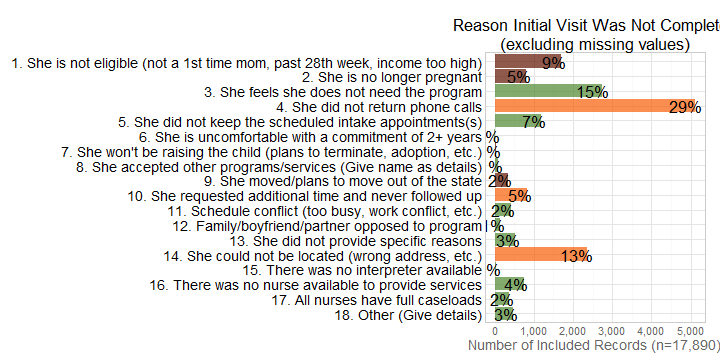

### Top Reasons Why Initial Visit Was Not Completed

| Response | Frequency |
| --- | --- |
| pending | 76 |
| no response to letters | 14 |
| trans to par-child connections | 14 |
| no permission to contact | 8 |
| not interested | 7 |
| no response to letter | 6 |
| unable to contact | 6 |
| lives in another county | 4 |
| lives out of service area | 3 |
| moved to tulsa | 3 |

# Clients Wants to Participate in C1

The following graphs describe the potential client's desire. A table displays the top open-ended responses why the potential client declined C1 services. The item stem is `RF23. Did the referred individual ever want to participate in the Children First program?`

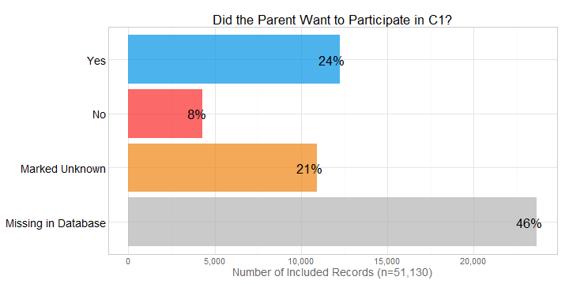

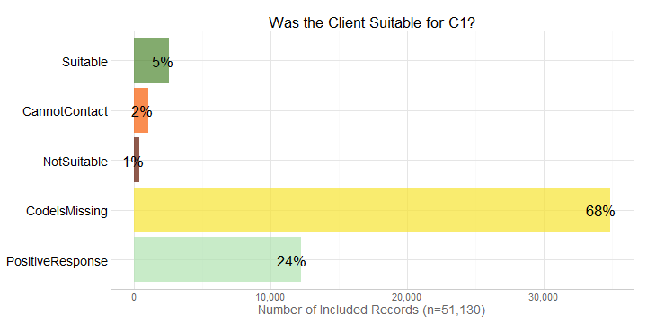

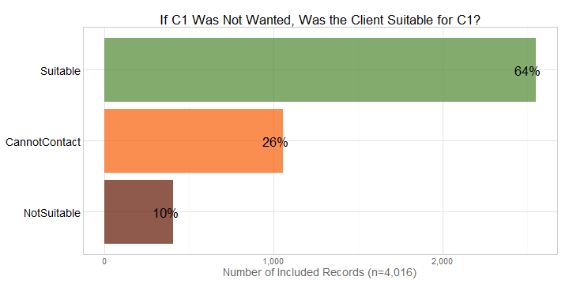

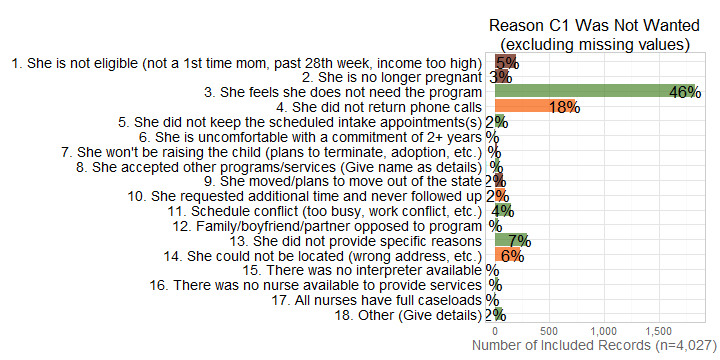

### Top Reasons Why Parent Never Wanted to Participate in C1

| Response | Frequency |
| --- | --- |
| pending | 4 |
| not interested | 3 |
| 3 | 2 |
| see above | 2 |
| abortion | 1 |
| already had baby | 1 |
| already has a 1 year old child | 1 |
| already has nurse home visitor | 1 |
| attempted visit | 1 |
| av - expired past 28 wk | 1 |

# Questions

## Unanswered Questions

1. In the 'Number of People in Family' graph, are any values less than 2 a mistake?

## Answered Questions

1. –

# Session Information

For the sake of documentation and reproducibility, the current report was build on a system using the following software.

```
Report created by wbeasley at 2014-06-09, 10:47 -0500
```

```
R version 3.1.0 Patched (2014-05-24 r65737)
Platform: x86_64-w64-mingw32/x64 (64-bit)

locale:
[1] LC_COLLATE=English_United States.1252  LC_CTYPE=English_United States.1252    LC_MONETARY=English_United States.1252
[4] LC_NUMERIC=C                           LC_TIME=English_United States.1252

attached base packages:
[1] stats     graphics  grDevices utils     datasets  methods   base

other attached packages:
[1] RODBC_1.3-10       stringr_0.6.2      dplyr_0.2          lubridate_1.3.3    ggplot2_1.0.0      RColorBrewer_1.0-5
[7] scales_0.2.4       plyr_1.8.1         knitr_1.6

loaded via a namespace (and not attached):
 [1] assertthat_0.1   colorspace_1.2-4 digest_0.6.4     evaluate_0.5.5   formatR_0.10     grid_3.1.0
 [7] gtable_0.1.2     labeling_0.2     magrittr_1.0.1   MASS_7.3-33      memoise_0.2.1    munsell_0.4.2
[13] parallel_3.1.0   proto_0.3-10     Rcpp_0.11.1      reshape2_1.4     testit_0.3       tools_3.1.0
```